# Diversity analysis

2018-03-11 18:59:37

This is an attempt at a streamlined and yet complete, relatively *a priori*/non- snooped model analysis. **Note** that this version is an overhaul, with some missing components from the older results: see `MixedEffects_older.Rmd` …

Some parts of the analysis have been moved into separate `.R` files: the overall workflow is

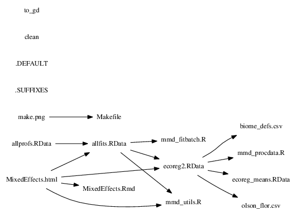

(`mmd_procdata` is out of date: Enric has processing machinery to extract lat/long of centroid of largest polygon (?) (`x`/`y` in the data set) and area …)

```r
source("mmd_utils.R")
source("gamm4_utils.R")
```

Packages used/versions:

```r
load_all_pkgs()
theme_set(theme_bw())
zmargin <- theme(panel.spacing=grid::unit(0,"lines"))
zmarginx <- theme(panel.spacing.x=grid::unit(0,"lines"))
library('pander')  ## for tables
sapply(pkgList,function(x) format(packageVersion(x)))
```

```
##         lme4        gamm4        bbmle        broom  broom.mixed
##     "1.1.16"      "0.2.5"     "1.0.20"      "0.4.3"      "0.0.1"
##      lattice    gridExtra      ggplot2      viridis       plotly
##    "0.20.35"        "2.3" "2.2.1.9000"      "0.5.0"      "4.7.1"
##      cowplot     ggstance        dplyr        tidyr       tibble
##      "0.9.2"        "0.3"      "0.7.4"      "0.8.0"      "1.4.2"
##        remef       r2glmm
## "1.0.6.9000"      "0.1.2"
```

```r
comb_out <- function(p,fn,...) {
    print(p)
    htmlwidgets::saveWidget(ggplotly(p,...),fn)
}
```

Note that you now need the *development* version of `lme4`, i.e. `devtools::install_github("lme4/lme4")`.

Data from Enric (includes area and lat/long coordinates):

```r
L <- load("ecoreg.RData")
```

Limit all observations with all predictor variables > 0 and no biome 98/99; set `biome` as factor. Log and scale/center variables as appropriate. This leaves us with 29 variables and 620 observations.

## Model fitting

This can now be done semi-automatically (i.e., fit all combinations of random effects) by using the function `fit_all` from the `mmd_utils.R` file (sourced above), e.g. `fit_all(response="mbirds_log")`

The `mmd_fitbatch.R` code has already run all random-effects model combinations for all four response variables, both with `lme4` and with `gamm4`. `mmd_reduce.R` has reduced these to lists with components `sum` (summaries: AIC, singularity, etc.); `coef` (coefficients); and `pred` (fitted, residuals, etc.).

Load data:

```r
load("allfits_sum_lmer.RData")  ## 4 taxa x 27 fits, using lmer
load("allfits_sum_gamm4.RData") ## 4 taxa x 27 fits, using gamm4
```

```r
aictab1 <- lme4_res$sum %>%
    filter(AIC<8) %>%
    arrange(taxon,AIC) %>%
    mutate(AIC=round(AIC,1),
           model=shorten_modelname(model))
pander(select(aictab1,-best),emphasize.strong.rows=which(aictab1$best))
```

| taxon | model | AIC | singular | df |
| --- | --- | --- | --- | --- |
| **mamph_log** | **b=i/fr=i/b_FR=d** | **0** | **FALSE** | **20** |
| mamph_log | b=d/fr=i/b_FR=i | 3 | TRUE | 20 |
| mamph_log | b=d/fr=i/b_FR=d | 3.9 | TRUE | 24 |
| mamph_log | b=d/fr=d/b_FR=i | 5.3 | TRUE | 24 |
| mamph_log | b=i/fr=d/b_FR=d | 5.5 | TRUE | 24 |
| mamph_log | b=i/fr=i/b_FR=f | 7.2 | FALSE | 30 |
| **mbirds_log** | **b=i/fr=i/b_FR=d** | **0** | **FALSE** | **20** |
| mbirds_log | b=i/fr=d/b_FR=d | 4.6 | TRUE | 24 |
| mbirds_log | b=i/fr=d/b_FR=f | 5.7 | TRUE | 34 |
| mbirds_log | b=i/fr=i/b_FR=f | 6.2 | TRUE | 30 |
| mbirds_log | b=d/fr=i/b_FR=d | 7.2 | TRUE | 24 |
| mmamm_log | b=i/fr=d/b_FR=f | 0 | TRUE | 34 |
| mmamm_log | b=i/fr=i/b_FR=f | 3.3 | TRUE | 30 |
| mmamm_log | b=d/fr=d/b_FR=f | 6.7 | TRUE | 38 |
| mmamm_log | b=i/fr=f/b_FR=f | 7.4 | TRUE | 44 |
| **mmamm_log** | **b=i/fr=d/b_FR=d** | **7.8** | **FALSE** | **24** |
| **plants_log** | **b=i/fr=i/b_FR=d** | **0** | **FALSE** | **20** |
| plants_log | b=d/fr=i/b_FR=i | 3 | TRUE | 20 |
| plants_log | b=d/fr=i/b_FR=d | 3.3 | TRUE | 24 |
| plants_log | b=i/fr=i/b_FR=f | 4.2 | TRUE | 30 |
| plants_log | b=i/fr=d/b_FR=d | 6.3 | TRUE | 24 |
| plants_log | b=d/fr=i/b_FR=f | 7.8 | TRUE | 34 |

Best (non-singular) models only:

```r
lme4_best_sum <- lme4_res$sum %>%
    filter(best) %>% select(-c(best,singular))
gamm4_best_sum <- gamm4_res$sum %>%
    filter(best) %>% select(-c(best,singular))
all_best_sum <- bind_rows(list(lme4=lme4_best_sum,gamm4=gamm4_best_sum),
                          .id="type")
pander(all_best_sum)
```

| type | taxon | model | AIC | df |
| --- | --- | --- | --- | --- |
| lme4 | plants_log | biome=int/flor_realms=int/biome_FR=diag | 0 | 20 |
| lme4 | mamph_log | biome=int/flor_realms=int/biome_FR=diag | 0 | 20 |
| lme4 | mbirds_log | biome=int/flor_realms=int/biome_FR=diag | 0 | 20 |
| lme4 | mmamm_log | biome=int/flor_realms=diag/biome_FR=diag | 7.835 | 24 |
| gamm4 | plants_log | biome=int/flor_realms=diag/biome_FR=int | 9.79 | 21 |
| gamm4 | mamph_log | biome=int/flor_realms=int/biome_FR=int | 22.63 | 17 |
| gamm4 | mmamm_log | biome=int/flor_realms=diag/biome_FR=int | 25.77 | 21 |
| gamm4 | mbirds_log | biome=int/flor_realms=int/biome_FR=int | 36.9 | 17 |

Our current strategy is to (1) take the best non-singular model fitted by `lme4`; (2) find the coefficients of the corresponding `gamm4` model. (Below, we also try taking the best non-singular `gamm4` model.)

```r
lme4_best_models <- select(lme4_best_sum,c(taxon,model))
gamm4_best_models <- select(gamm4_best_sum,c(taxon,model))
## keep only predictions from best models
gamm4_best_pred <- gamm4_res$pred %>%
    right_join(lme4_best_models,by=c("taxon","model"))
```

Fitted vs residual for all four taxa:

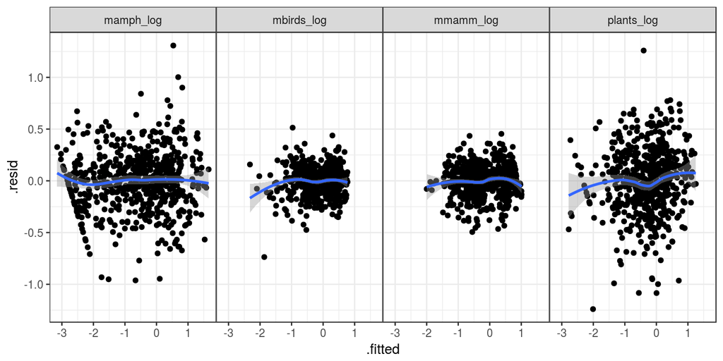

```r
ggplot(gamm4_best_pred,aes(.fitted,.resid))+
    geom_point()+geom_smooth()+
    facet_wrap(~taxon,nrow=1)+zmargin
```

A little bit heavy-tailed …

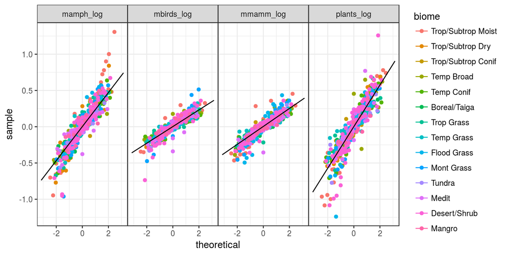

```r
## https://stackoverflow.com/questions/40598011/how-to-customize-hover-information-in-ggplotly-object
ggqq <- ggplot(gamm4_best_pred,aes(sample=.resid,
                                   colour=biome,
                                   flor_realms=flor_realms))+
    stat_qq()+stat_qq_line(aes(group=taxon))+
    facet_wrap(~taxon,nrow=1)+zmargin
comb_out(ggqq,"ggqq.html",tooltip=c("biome","flor_realms"))
```

(dynamic alternative)

## coefficient plot of all models tried

For example:

```r
gamm4_allcoef <- get_allcoefs(gamm4_res,"plants_log") %>% add_wald_ci
lme4_allcoef <- get_allcoefs(lme4_res,"plants_log") %>% add_wald_ci
gg_allcoef <- ggplot(gamm4_allcoef,aes(estimate,model,colour=singular,shape=singular))+
    ## use point + linerange because some RE are missing std.errors
    geom_point()+
    geom_linerangeh(aes(xmin=lwr,xmax=upr))+
    facet_wrap(~term,scale="free_x")+
    geom_vline(xintercept=0,lty=2)+
    scale_colour_brewer(palette="Set1")+
    zmarginx
```

All `gamm4` coefs for plants:

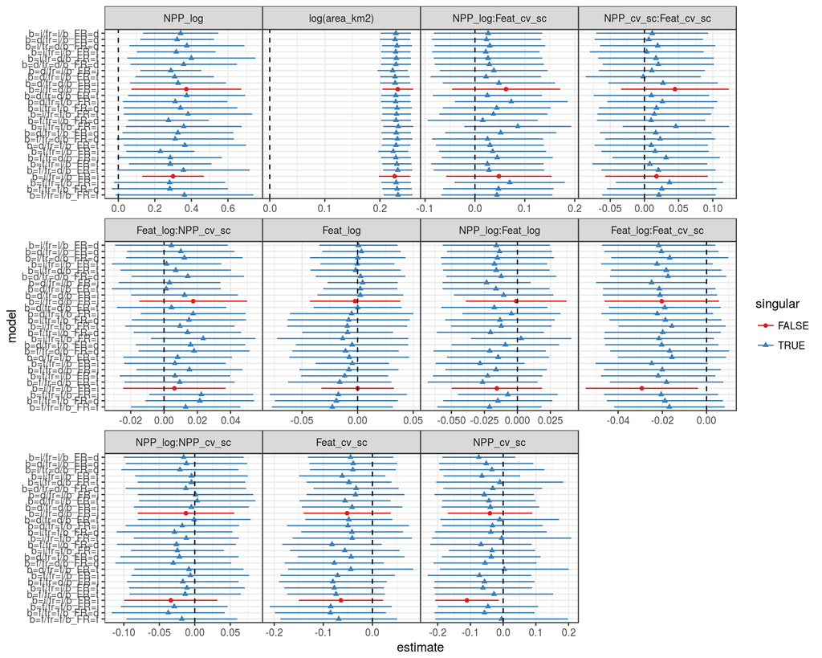

```r
print(gg_allcoef)
```

all `lme4` coefs for plants:

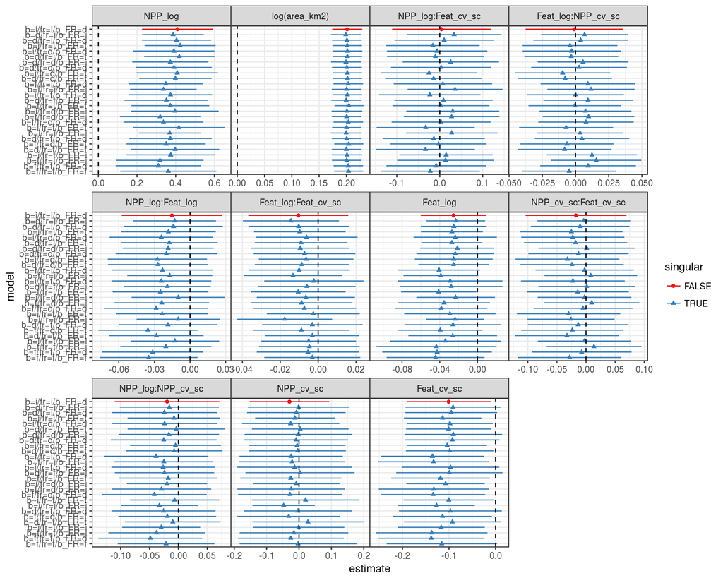

```r
print(gg_allcoef %+% lme4_allcoef)
```

**to do**: why so many singular now … ?

**to do**: redo profiling/profile plots, comparison of Wald/profile CIs (at least for best models …

Check difference between Wald and likelihood profile confidence intervals. In principle profile CIs are more accurate - **if** the computations have run reliably … but I would probably be conservative and take the wider of the two.

Pull out coefs from best models for `lme4`, `gamm4` (from `lme4`-best model), `gamm4` (from `gamm4`-best model)

```r
## lmer-best fits fitted via gamm4
gamm4_best_coef <- gamm4_res$coef %>%
    right_join(lme4_best_models,by=c("taxon","model")) %>%
    add_wald_ci %>% drop_intercept
## gamm4-best fits
gamm4_best2_coef <- gamm4_res$coef %>%
    right_join(gamm4_best_models,by=c("taxon","model")) %>%
    add_wald_ci %>% drop_intercept
## lmer-best fits
lme4_best_coef <- lme4_res$coef %>%
    right_join(lme4_best_models,by=c("taxon","model")) %>%
    add_wald_ci %>% drop_intercept
all_best_coef <- bind_rows(list(lme4=lme4_best_coef,gamm4=gamm4_best_coef,
                                gamm4_2=gamm4_best2_coef),
                           .id="type")
```

**to do**: plot all coefficients including std devs (need to combine group with term for random effects)

Exclude random effects and `NPP_log` (which is large and significant for all taxa). **Abuse warning**: coloring significant effects. **Snooping warning**: counting number of sig values for each model type!

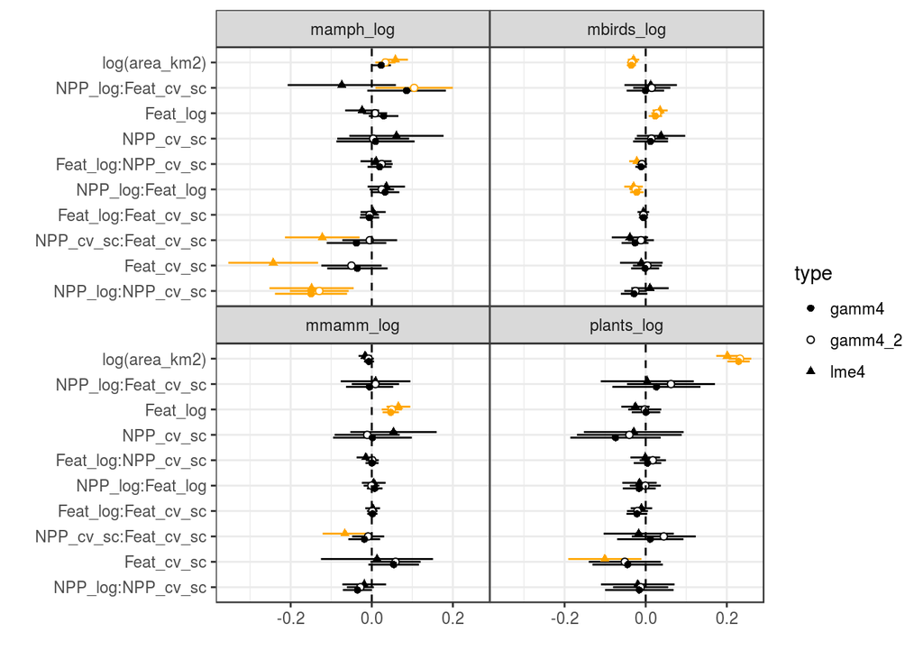

There are not a lot of effects other than `NPP_log` that are consistently large and significant; perhaps main effects of fire for birds and mammals. Amphibians have considerably larger effects (the last three: Feat cv and its interactions).

Enric and I decided that it was probably best to go with the gamm4-best models, with some caution expressed about the effects that were marginal. Here are the final(ish?) results, with NPP effects added back in:

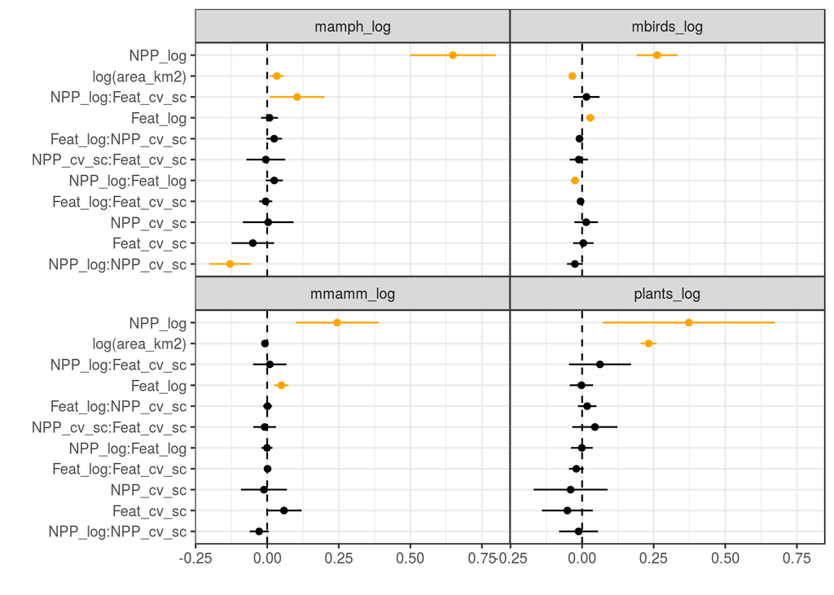

## Plotting functions

Load best non-singular gamm4 fits:

```r
load("bestmodels_gamm4.RData")
names(best_models)
```

```
## [1] "plants_log" "mamph_log"  "mbirds_log" "mmamm_log"
```

`plotfun()` takes arguments:

- `model`: fitted model
- `xvar` (“NPP_log”): x-variable
- `auxvar` (“Feat_cv_sv”): auxiliary variable (e.g. for examining interactions)
- `respvar` (equal to model response by default): response variable
- `aux_quantiles`: (0.1, 0.5, 0.9) quantiles of auxiliary variable to predict
- `pred_lower_lim` (-3) : lower cut off values (log scale)
- `data` (ecoreg)
- `re.form` (NA) which RE to include in *predictions* (default is none)

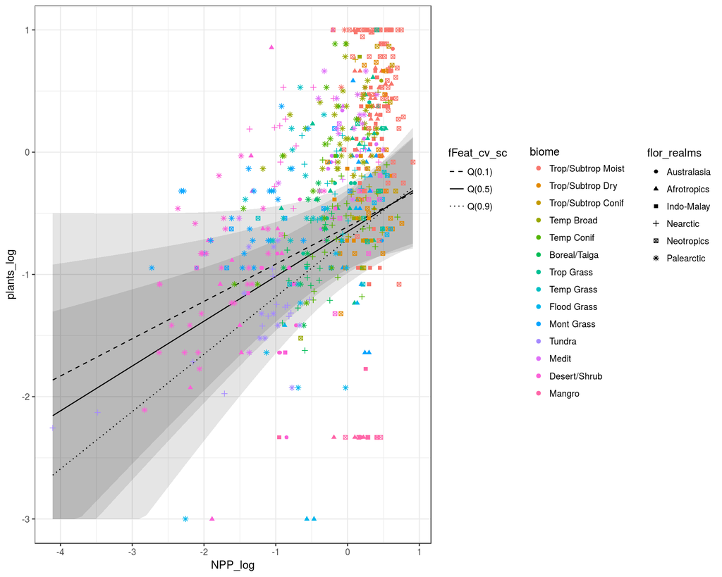

```r
ggplot1 <- plotfun(best_models[[1]])
comb_out(ggplot1,"ggplot1.html")
```

(dynamic alternative)

Partial residuals:

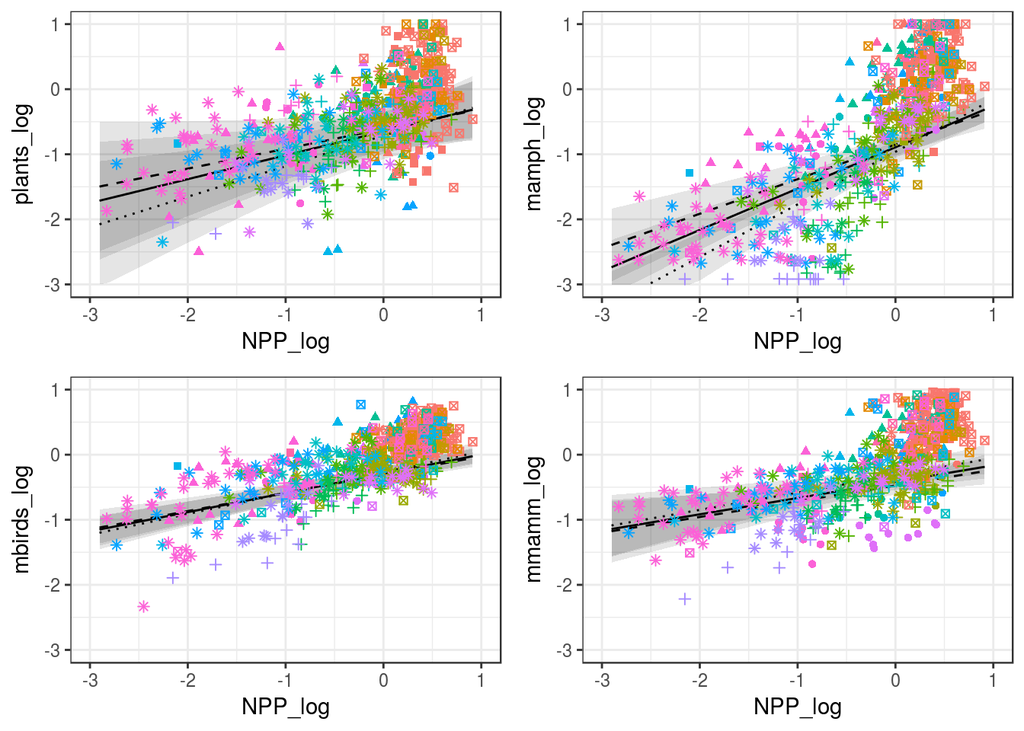

```r
## fix_NAs needed for remef() results: remef_allran does it automatically
fix_NAs <- function(rem,model) {
    if (!is.null(nastuff <- attr(model.frame(model),"na.action"))) {
        return(napredict(nastuff,rem))
    } else return(rem)
}
remef_plots <- lapply(best_models,
      function(m) {
    rem1 <- remef_allran(m,ecoreg)
    if (length(rem1)==nrow(ecoreg)) {
        ## if it worked ...
        ecoreg$rem1 <- rem1
        ## update previous plot:
        plotfun(m,respvar="rem1",data=ecoreg)+theme(legend.position="none")+
            scale_x_continuous(limits=c(-3,1))
    }
})
do.call(grid.arrange,remef_plots)
```

A dynamic version of the plants results

## $R^2$ across taxa

```r
all_rsq <- bind_rows(lapply(best_models,
                            function(x) r2beta(x$mer)),.id="taxon") %>%
    mutate(Effect=as.character(Effect),
           Effect=gsub("^X","",Effect),
           Effect=reorder(factor(Effect),Rsq))
```

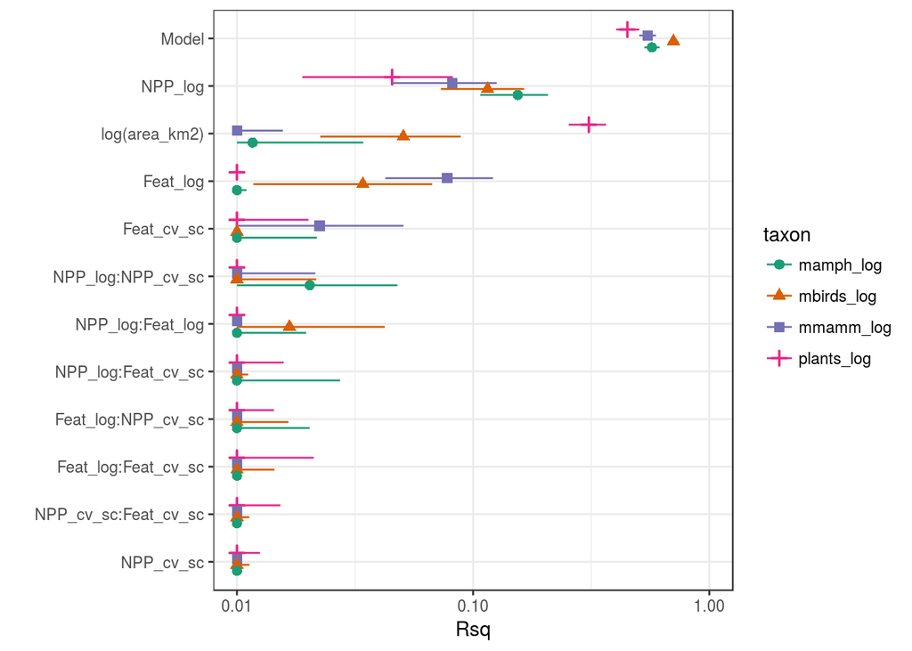

```r
rsqplot <- ggplot(all_rsq,aes(Rsq,Effect,colour=taxon,shape=taxon))+
    geom_pointrangeh(aes(xmin=lower.CL,xmax=upper.CL),
                   position=position_dodgev(height=0.5))+
    scale_colour_brewer(palette="Dark2")+
    scale_x_log10(limits=c(1e-2,1),oob=scales::squish)+
    labs(y="")
print(rsqplot)
```

## Models fitted with only biome and flor_realms

(from `mmd_fitbatch2.R`): diagonal (independent) random effects at the biome and flor realm level.

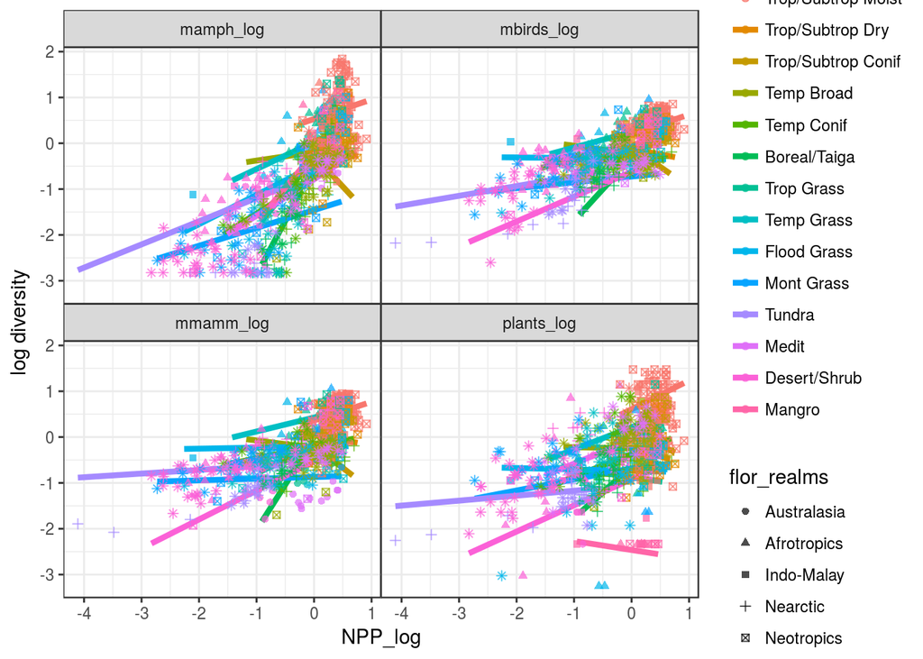

```r
load("allfits_restr_gamm4.RData")
predList <- lapply(allfits_restr_gamm4,
       predfun,
       auxvar=NULL,grpvar="biome",
       re.form=~(1+NPP_log|biome))
set.focal <- function(n,d) { d$focal <- d[[n]]; return(d) }
predList <- Map(set.focal,names(predList),predList)
predFrame <- bind_rows(predList,.id="taxon")
dList <- setNames(replicate(4,ecoreg,simplify=FALSE),names(predList))
dList <- Map(set.focal,names(dList),dList)
dFrame <- bind_rows(dList,.id="taxon")
ggplot(predFrame,aes(x=NPP_log,y=focal,colour=biome))+
    geom_line(lwd=1.5)+
    geom_point(data=dFrame,aes(shape=flor_realms),alpha=0.7)+
    facet_wrap(~taxon)+zmargin+
    labs(y="log diversity")
```

Extract coefficients:

In this particular case the effect of NPP only varies across floristic realms, so the picture isn’t especially pretty:

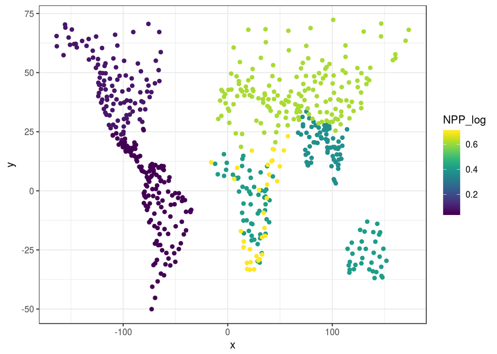

```r
coefs_plants <- merge_coefs(ecoreg,best_models[[1]])
ggplot(coefs_plants,aes(x,y,colour=NPP_log))+
    geom_point()+
    scale_colour_viridis()
```